# Bayesian Statistics: A practical introduction

Lab 2

Richard D. Morey, Cardiff University (richarddmorey@gmail.com)

Each example contains R code for you to run by cutting and pasting the code from the document into R. The output should look similar to the output in the document below.

Before you start, you should change your R working directory to whatever directory you have stored this lab file in. This can be done through the `File...` menu in Windows, or in all platforms using the `setwd()` function.

## Hierarchical modeling

### Setup

See Jackman (2009) offers the following Example 7.6 (page 323).

> ANOVA. The 1982 High School and Beyond Survey is a nationally representative sample of US public and Catholic schools, covering 7185 students in 160 schools. The chief outcome of interest is a standardized measure of math ability, with a mean of 12.75 and IQR of [7.28, 18.32]. These data figure prominently in the standard reference on hierarchical linear models (Raudenbush and Bryk 2002), and so are well suited for our purposes here. We fit a one-way ANOVA model (Equation 7.1 in Example 7.1), recognizing that students are grouped by school. We momentarily ignore school type (public vs Catholic) and other school-level characteristics…

The code to run the analysis is in `oneWay.R`. Remember to change R’s working directory, and to load the `nimble` library. See the BUGS code on `oneWay2.bug`, and make sure you understand the model.

### Data preparation

First we prepare packages and read in the data.

```r
library(multilevel)
library(nimble)
library(mcmc)

# Read in the data using the code in the dataPrep.R
source('dataPrep.R')
```

We can now examine the structure of the data. Each row is a student.

```r
DT::datatable(data1, options = list(pageLength = 5))
```

|  | school | minority | female | ses | math |
| --- | --- | --- | --- | --- | --- |
| 1 | 1224 | 0 | 0 | 0.022 | 4.583 |
| 2 | 1224 | 0 | 0 | 0.332 | 20.349 |
| 3 | 1224 | 0 | 0 | 0.372 | 6.714 |
| 4 | 1224 | 0 | 0 | -0.078 | 16.405 |
| 5 | 1224 | 0 | 0 | -0.158 | 17.898 |
| 6 | 1224 | 0 | 0 | -0.298 | 19.338 |
| 7 | 1224 | 0 | 0 | -0.458 | 21.521 |
| 8 | 1224 | 0 | 0 | -0.468 | 3.154 |
| 9 | 1224 | 0 | 0 | -0.468 | 21.178 |
| 10 | 1224 | 0 | 0 | -0.528 | 20.349 |

[output cut: 7175 more lines]

We also have access to school level covariates in the data frame `data2`.

```r
## Summarise the column of interest
summary(data1$math)
```

```
##    Min. 1st Qu.  Median    Mean 3rd Qu.    Max.
##  -2.832   7.275  13.131  12.748  18.317  24.993
```

Now we can look at the counts of the students and schools in the data set.

```r
## How many students in each school are there?
table(data1$school)
```

```
##
## 1224 1288 1296 1308 1317 1358 1374 1433 1436 1461 1462 1477 1499 1637 1906 1909
##   47   25   48   20   48   30   28   35   44   33   57   62   53   27   53   28
## 1942 1946 2030 2208 2277 2305 2336 2458 2467 2526 2626 2629 2639 2651 2655 2658
##   29   39   47   60   61   67   47   57   52   57   38   57   42   38   52   45
## 2755 2768 2771 2818 2917 2990 2995 3013 3020 3039 3088 3152 3332 3351 3377 3427
##   47   25   55   42   43   48   46   53   59   21   39   52   38   39   45   49
## 3498 3499 3533 3610 3657 3688 3705 3716 3838 3881 3967 3992 3999 4042 4173 4223
##   53   38   48   64   51   43   45   41   54   41   52   53   46   64   44   45
## 4253 4292 4325 4350 4383 4410 4420 4458 4511 4523 4530 4642 4868 4931 5192 5404
##   58   65   53   33   25   41   32   48   58   47   63   61   34   58   28   57
## 5619 5640 5650 5667 5720 5761 5762 5783 5815 5819 5838 5937 6074 6089 6144 6170
##   66   57   45   61   53   52   37   29   25   50   31   29   56   33   43   21
## 6291 6366 6397 6415 6443 6464 6469 6484 6578 6600 6808 6816 6897 6990 7011 7101
##   35   58   60   54   30   29   57   35   56   56   44   55   49   53   33   28
## 7172 7232 7276 7332 7341 7342 7345 7364 7635 7688 7697 7734 7890 7919 8009 8150
##   44   52   53   48   51   58   56   44   51   54   32   22   51   37   47   44
## 8165 8175 8188 8193 8202 8357 8367 8477 8531 8627 8628 8707 8775 8800 8854 8857
##   49   33   30   43   35   27   14   37   41   53   61   48   48   32   32   64
## 8874 8946 8983 9021 9104 9158 9198 9225 9292 9340 9347 9359 9397 9508 9550 9586
##   36   58   51   56   55   53   31   36   19   29   57   53   47   35   29   59
```

```r
## How many schools?
length(unique(data1$school))
```

```
## [1] 160
```

To see if it will be important to include school as a covariate, we compute the intra-class correlation to see if `school` adds a substantial amount of variance. In this case, the ICC is an estimate of
$$\frac{\sigma^2_{\mbox{school}}}{\sigma^2_{\mbox{school}} +
\sigma^2_\epsilon}$$
The ICC measures the relative contribution of the random schools and random error to the variance in the data.

```r
## First, perform a classical one-way ANOVA
classical <- aov(math ~ as.factor(school),
                 data = data1)
summary(classical)
```

```
##                     Df Sum Sq Mean Sq F value Pr(>F)
## as.factor(school)  159  64907   408.2   10.43 <2e-16 ***
## Residuals         7025 274970    39.1
## ---
## Signif. codes:  0 '***' 0.001 '**' 0.01 '*' 0.05 '.' 0.1 ' ' 1
```

```r
## intra-class correlation
multilevel::ICC1(classical)
```

```
## [1] 0.1735383
```

It seems that the intraclass correlation coefficient is moderately high. We should include school in our model.

### Part 1: Fitting the hierarchical model

We will fit the hierarchical model built in `oneWay2.bug`, listed below:

```
model{
    ## loop over the student-level data
    for(i in 1:Nstudents){
          ## j is a variable (nested indexing)
          math[i] ~ dnorm(alpha[j[i]], tau.eps)
    }

    ## loop over the J schools (level 2)
    for(p in 1:J){
          alpha[p] ~ dnorm(mu0, tau.alpha)
    }

    ## priors on hyperparameters
    mu0 ~ dnorm(0, .0001)

    ## uniform priors on standard deviations
    sigma.eps ~ dunif(0, 10)
  sigma.alpha ~ dunif(0, 10)

    ## convert the standard deviations to precisions
    tau.eps <- pow(sigma.eps, -2)
    tau.alpha <- pow(sigma.alpha, -2)

}
```

What are the variables?

| Variable name | Type | Length | Description |
| --- | --- | --- | --- |
| `math` | data | Number of students | the math score of the `i`th student |
| `Nstudents` | data | 1 | Total number of students |
| `alpha` | parameter | Number of schools | the effect of being in `p`th school |
| `j` | index | Number of students | an index telling us which school the `i`th student attends |
| `tau.eps` | parameter | 1 | Precision (inverse of variance) of math scores within schools |
| `J` | data | 1 | Total number of schools |
| `mu0` | parameter | 1 | Grand mean math performance of across schools |
| `tau.alpha` | parameter | 1 | Precision of mean math scores across schools |
| `sigma.eps` | parameter | 1 | Standard deviation of math scores within schools |
| `sigma.alpha` | parameter | 1 | Standard deviation of mean math scores across schools |

```r
## Create the data to pass to Nimble
forNimble <- list()
forNimble$math <- data1$math
forNimble$Nstudents = length(data1$math)
forNimble$j <- match(data1$school,     ## indexes which school we're in
                   unique(data1$school))
forNimble$J <- max(forNimble$j)          ## number of schools

## initialize the Gibbs sampler with starting values
## this is not necessary most of the time.
inits <- list(mu0=mean(forNimble$math),
              alpha=tapply(forNimble$math,
                forNimble$j,mean)     ## school-specific means
              )

nimble.model <- nimble::readBUGSmodel(
  model="oneway2.bug",
  data=forNimble,
  inits=inits)
```

```
## Defining model
```

```
##   [Note] Using 'math' (given within 'constants') as data.
```

```
## Building model
```

```
## Setting data and initial values
```

```
## Running calculate on model
##   [Note] Any error reports that follow may simply reflect missing values in model variables.
```

```
## Checking model sizes and dimensions
```

```
##   [Note] This model is not fully initialized. This is not an error.
##          To see which variables are not initialized, use model$initializeInfo().
##          For more information on model initialization, see help(modelInitialization).
```

```r
## get 4k iterations
compiled.model = compileNimble(nimble.model)
```

```
## Compiling
##   [Note] This may take a minute.
##   [Note] Use 'showCompilerOutput = TRUE' to see C++ compilation details.
```

```r
conf <- configureMCMC(nimble.model)
conf$addMonitors(c("mu0", "sigma.alpha", "sigma.eps", "alpha"))

# Build the MCMC
Rmcmc <- buildMCMC(conf)
Cmcmc <- compileNimble(Rmcmc, project = compiled.model)
```

```
## Compiling
##   [Note] This may take a minute.
##   [Note] Use 'showCompilerOutput = TRUE' to see C++ compilation details.
```

```r
runMCMC(Cmcmc, niter = 4000) |>
  as.mcmc() -> samples
```

```
## running chain 1...
```

Let’s first check one of our convergence statistics.

```r
## Geweke diagnostic
gd = geweke.diag(samples)

## Extract the z scores from the object
geweke.z.scores = gd$z

## plot the cumulative distribution of the z scores
plot(ecdf(geweke.z.scores), xlab = "Geweke diagnostic z score")

## Add the theoretical line (standard normal)
curve( pnorm(x), xlim = par()$usr[1:2], add = TRUE, lwd = 2, col="red")
```

[output not shown]

We now make a PDF file containing plots of all the chains. We make a PDF because it is easier to page through a PDF than a lot of R plots.

```r
## see summaries for all of the output
summary(samples)

## Dump a PDF with all chains
pdf('chains.pdf', version = "1.4")
plot(samples)
dev.off()
```

Compare the hierarchical estimates of the school means with the nonhierarchical school means (use `aggregate()` or `tapply()` to find the group means). What do you expect to see? Is this what you find?

#### Solution

We first gather the observed means and the point estimates of the $\alpha$ parameters, the hierarchical means of the schools.

```r
## Use aggregate to compute the observed mean math score per school
observed.means = aggregate(math ~ school, data = data1, mean)

## Compute the posterior means of the alpha parameters
## to use as point estimates
alphas = samples[,1:160]
alpha.est = colMeans(alphas)
```

We can now plot the two estimates against one another.

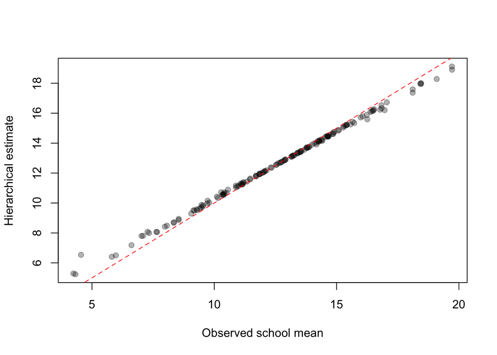

```r
plot(observed.means$math, alpha.est,
     ylab = "Hierarchical estimate",
     xlab = "Observed school mean",
     col = rgb(0,0,0,.3), pch = 19)
abline(0,1, lty = 2, col="red")
```

Notice the moderate hierarchical shrinkage.

### Part 2: Assessing the variance in schools

Compute a Bayesian posterior for the intraclass correlation coefficient using the values from the MCMC chain.

1. Use reparametrization to compute the two variances of interest.
2. Compute a chain of ICC values using the definition of the ICC above.
3. Compute the posterior mean and 95% credible interval.
4. Plot the posterior.

Does the Bayesian ICC agree with the classical ICC?

#### Solution

We first compute the two variances we need to compute the Bayesian ICC. Remember that we have two parameters that represent standard deviations, so we can use these to compute the variances.

```r
## Bayesian ICC
sigma2.eps = samples[,'sigma.eps']^2
sigma2.alpha = samples[,'sigma.alpha']^2
```

Remember that `sigma2.eps` and `sigma2.alpha` are both vectors of values; they are MCMC chains.

We can use the formula for the ICC to compute a new vector (MCMC chain) of values that represent posterior samples of the ICC.

```r
## Create a chain for the Bayesian estimate of the ICC
bayes.icc = sigma2.alpha / (sigma2.alpha + sigma2.eps)

## Convert the vector to an mcmc object for convenience
bayes.icc = mcmc(bayes.icc)
```

Now that we have a vector of values, it is easy to compute posterior quantities of interest.

```r
summary(bayes.icc)
```

```
##
## Iterations = 1:4000
## Thinning interval = 1
## Number of chains = 1
## Sample size per chain = 4000
##
## 1. Empirical mean and standard deviation for each variable,
##    plus standard error of the mean:
##
##           Mean             SD       Naive SE Time-series SE
##      0.1840218      0.0269585      0.0004263      0.0012828
##
## 2. Quantiles for each variable:
##
##   2.5%    25%    50%    75%  97.5%
## 0.1486 0.1697 0.1820 0.1947 0.2260
```

We can also plot the posterior of the Bayesian ICC and add the classical ICC for comparison.

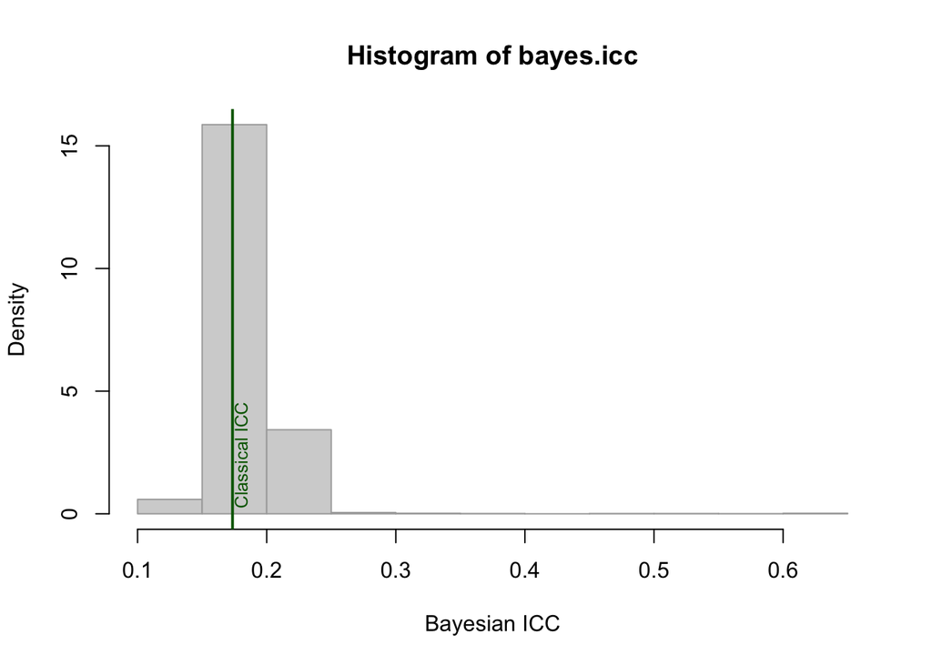

```r
## Plot the posterior
hist(bayes.icc, col="lightgray",
     border = "darkgray", freq = FALSE,
     xlab = "Bayesian ICC")

## Add the classical value to the plot, in green
abline(v = multilevel::ICC1(classical), col = "darkgreen", lwd=2)
text(multilevel::ICC1(classical), par()$usr[3],
     "Classical ICC", adj = c(-.2,1.2), srt=90,
     col = "darkgreen", cex = .8)
```

Notice how easy it was to obtain a credible interval for the Bayesian ICC. For many quantities, it will be quite difficult to obtain a classical confidence interval, yet a Bayesian credible interval will be easily obtainable from the MCMC chain.

#### Another perspective

Another (complementary) way we can view the problem is to look at the estimates of the $\alpha$ parameters.

Recall that `alphas` contains our chains for the alpha parameters and `alpha.est` contains the posterior means. We now compute the 95% credible intervals for each $\alpha$.

```r
## Use apply() to compute central 95% credible intervals
CIs = apply(alphas, 2, function(v) quantile(v, p = c(.025, .975)))
```

We want to plot these estimates and CIs in a way that will enable us to visualize variance of the schools. A cumulative distribution plot, with error bars, is one good way of doing this.

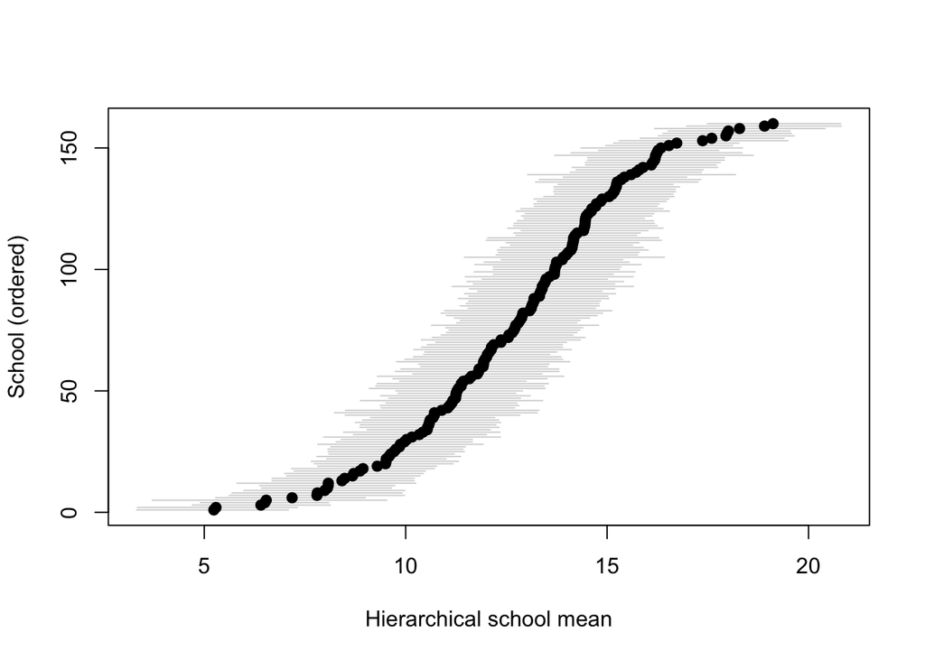

```r
## We need to reorder the estimates and CIs together, so we define a
## variable to keep track of the ordering
ord = order(alpha.est)

## Plot the school means, in order from worst to best (using ord)
plot(alpha.est[ord], 1:length(alpha.est),
     xlim = range(CIs),
     pch = 19, ylab = "School (ordered)",
     xlab = "Hierarchical school mean")

## Add the corresponding credible intervals
segments(CIs[1,ord], 1:length(alpha.est),
         CIs[2,ord], 1:length(alpha.est),
         col = rgb(0,0,0,.2))
```

As can be seen, the variability of the schools is substantial compared to the credible intervals.

### Part 3: Adding a school-level covariate

Choose a school-level covariate to add to the model. The school-level covariates are contained in the data frame `data2`, which has the following structure. Each row is a school.

|  | school | size | cath | academic | disclimate | minority | meanses |
| --- | --- | --- | --- | --- | --- | --- | --- |
| 1 | 1224 | 842 | 0 | 0.35 | 1.597 | 0 | -0.428 |
| 2 | 1288 | 1855 | 0 | 0.27 | 0.174 | 0 | 0.128 |
| 3 | 1296 | 1719 | 0 | 0.32 | -0.137 | 1 | -0.42 |
| 4 | 1308 | 716 | 1 | 0.96 | -0.622 | 0 | 0.534 |
| 5 | 1317 | 455 | 1 | 0.95 | -1.694 | 1 | 0.351 |
| 6 | 1358 | 1430 | 0 | 0.25 | 1.535 | 0 | -0.014 |
| 7 | 1374 | 2400 | 0 | 0.5 | 2.016 | 0 | -0.007 |
| 8 | 1433 | 899 | 1 | 0.96 | -0.321 | 0 | 0.718 |
| 9 | 1436 | 185 | 1 | 1 | -1.141 | 0 | 0.569 |
| 10 | 1461 | 1672 | 0 | 0.78 | 2.096 | 0 | 0.683 |

[output cut: 150 more lines]

(The solution uses school size.)

#### Solution

I chose to add in the size of the school as a covariate. It makes sense to “center” the school and create a “school size ratio”, of which we will take the logarithm (base 2). This means the slope can be interpreted as the change in mean math score for every doubling of the school size.

This answers the question of *whether school size has an effect on math scores.*

Our school-level covariates are in `data2`. We construct our centered school size covariate called `size`…

```r
size = log2(data2$size) - mean(log2(data2$size))
```

…and then include it in the object we will pass to `nimble`:

```r
## Create the data to pass to nimble
forNimble <- list()
forNimble$math <- data1$math
forNimble$Nstudents = length(data1$math)
forNimble$j <- match(data1$school,     ## indexes which school we're in
                   unique(data1$school))
forNimble$J <- max(forNimble$j)          ## number of schools
forNimble$size <- size
```

The BUGS file is shown below.

```
model{
    ## loop over the student-level data
    for(i in 1:Nstudents){
          ## j is a variable (nested indexing)
          math[i] ~ dnorm(alpha[j[i]], tau.eps)
    }

    ## loop over the J schools (level 2)
    for(p in 1:J){
          alpha.pred[p] <- mu0 + beta.size * size[p]
          alpha[p] ~ dnorm(alpha.pred[p] , tau.alpha)
    }

    ## priors on hyperparameters
    mu0 ~ dnorm(0, .0001)
    beta.size ~ dnorm(0, .0001)

    ## uniform priors on standard deviations
    sigma.eps ~ dunif(0, 10)
    sigma.alpha ~ dunif(0, 10)

    ## convert the standard deviations to precisions
    tau.eps <- pow(sigma.eps, -2)
    tau.alpha <- pow(sigma.alpha, -2)

}
```

We now have all the information we need to fit the model. Note that we need to include the new parameter `beta.size` in the initialization object.

```r
## initialize the Gibbs sampler with starting values
## this is not necessary most of the time.
inits <- list(mu0 = mean(forNimble$math),
              alpha = tapply(forNimble$math,
                forNimble$j,mean),     ## school-specific means
              beta.size = 0)
```

We compile and sample from the model.

```r
## compile Nimble model
nimble.model <- nimble::readBUGSmodel(
  model="solution_bug/oneway3.bug",
  data=forNimble,
  inits=inits)
```

```
## Defining model
```

```
##   [Note] Using 'math' (given within 'constants') as data.
```

```
## Building model
```

```
## Setting data and initial values
```

```
## Running calculate on model
##   [Note] Any error reports that follow may simply reflect missing values in model variables.
```

```
## Checking model sizes and dimensions
```

```
##   [Note] This model is not fully initialized. This is not an error.
##          To see which variables are not initialized, use model$initializeInfo().
##          For more information on model initialization, see help(modelInitialization).
```

```r
## get 4k iterations
compiled.model = compileNimble(nimble.model)
```

```
## Compiling
##   [Note] This may take a minute.
##   [Note] Use 'showCompilerOutput = TRUE' to see C++ compilation details.
```

```r
conf <- configureMCMC(nimble.model)
conf$addMonitors(c("mu0", "sigma.alpha", "sigma.eps", "alpha", "beta.size"))

# Build the MCMC
Rmcmc <- buildMCMC(conf)
Cmcmc <- compileNimble(Rmcmc, project = compiled.model)
```

```
## Compiling
##   [Note] This may take a minute.
##   [Note] Use 'showCompilerOutput = TRUE' to see C++ compilation details.
```

```r
runMCMC(Cmcmc, niter = 4000) |>
  as.mcmc() -> samples
```

```
## running chain 1...
```

Note that we now include `beta.size` as a parameter to monitor.

We can now plot the posterior distribution for the `beta.size` parameter…

```r
summary(samples[,"beta.size"])
```

```
##
## Iterations = 1:4000
## Thinning interval = 1
## Number of chains = 1
## Sample size per chain = 4000
##
## 1. Empirical mean and standard deviation for each variable,
##    plus standard error of the mean:
##
##           Mean             SD       Naive SE Time-series SE
##      -0.068779       0.238542       0.003772       0.004225
##
## 2. Quantiles for each variable:
##
##     2.5%      25%      50%      75%    97.5%
## -0.53438 -0.22619 -0.06887  0.09009  0.40360
```

…and plot the marginal posterior:

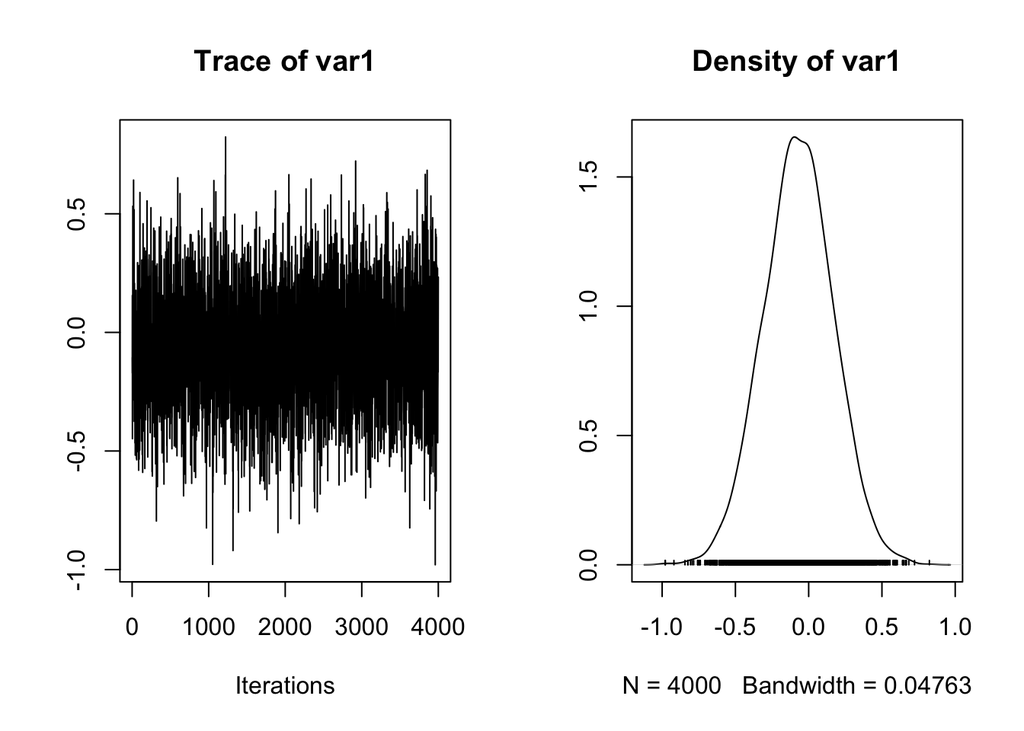

```r
plot(samples[,"beta.size"])
```

Recall that we estimated the observed school means in part 1, so we can use this to check our answer. We will plot the observed means against the school size variable, and then add a regression line based on the Bayesian estimates.

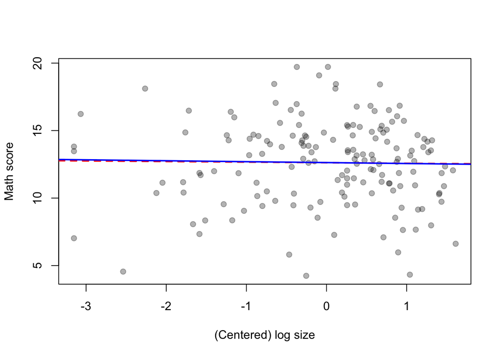

```r
plot(size, observed.means$math, ylab = "Math score", xlab = "(Centered) log size", pch = 19, col = rgb(0,0,0,.3))

## Compute the Bayesian point estimates
intercept = mean(samples[,"mu0"])
slope = mean(samples[,"beta.size"])

## classical (non-hierarchical) regression line in red
abline(lm(observed.means$math~size), col = "red", lwd=2, lty=2)

## Bayesian regression line in blue
abline(intercept, slope, col = "blue", lwd=2, lty=1)
```

The results agree. The difference between the two is that the hierarchical model can estimate “proper” standard errors, accounting for uncertainty at all levels (student and school) whereas the classical estimates are based on aggregation across students, and hence cannot take into account the uncertainty at that level.

```r
## Posterior standard deviation of the intercept
sd(samples[,"mu0"])
```

```
## [1] 0.2548001
```

```r
## Posterior standard deviation of beta
sd(samples[,"beta.size"])
```

```
## [1] 0.2385422
```

```r
## Classical (non-hierarchical) regression
summary(lm(observed.means$math~size))
```

```
##
## Call:
## lm(formula = observed.means$math ~ size)
##
## Residuals:
##     Min      1Q  Median      3Q     Max
## -8.3921 -2.1660  0.2787  2.0116  7.0992
##
## Coefficients:
##             Estimate Std. Error t value Pr(>|t|)
## (Intercept) 12.62075    0.24722  51.050   <2e-16 ***
## size        -0.04385    0.23703  -0.185    0.853
## ---
## Signif. codes:  0 '***' 0.001 '**' 0.01 '*' 0.05 '.' 0.1 ' ' 1
##
## Residual standard error: 3.127 on 158 degrees of freedom
## Multiple R-squared:  0.0002165,  Adjusted R-squared:  -0.006111
## F-statistic: 0.03422 on 1 and 158 DF,  p-value: 0.8535
```

Though, to be fair, the results are nearly identical in this particular case owing to the moderately-high, and roughly equal, number of observations in each school.